# Ensemble Network Aggregation

## Define Simulation Settings

```r
SIZE <- c("tiny", "small", "moderate", "middle", "large")
NP <- as.character(c(20, 50, 100, 200, 500, 1000))
NOISE <- as.character(c(0.25, 0.5, 1, 1.5))
BOOTSTRAP_COUNT <- 140

set.seed(1234)
library(knitr)
```

## Simulate Networks

We'll first define the function used to simulate the networks.

```r
#' Read the edge definition and simulate the regulation ###
#'
#' @param size should be one of
#' c('tiny','small','moderate','middle','large', 'huge') @param sample can
#' be any positive number.  @param noise can be any positive number (for
#' our study, we should try 0.25, 0.5, 0.75, 1, 1.5 and 2) @author
#' Guanghua Xiao \email{Guanghua.Xiao@@UTSouthwestern.edu}
network.simulation <- function(size, sample, noise, outputDir) {
    dir.create(outputDir)
    dat <- read.csv(paste("../truth/", size, ".csv", sep = ""))

    dat <- dat[dat$Source != dat$Target, ]
    dat[dat$Source > dat$Target, ] <- dat[dat$Source > dat$Target, 2:1]
    dat[dat$Source > dat$Target, ]

    Gene <- union(dat$Source, dat$Target)
    nGene <- length(Gene)

    N <- dim(dat)[1]
    dat$regulation <- round(sign(rbinom(N, 1, 0.5) - 0.5) * rnorm(N, 0.5, 0.2),
        2)
    dat$type <- sign(dat$regulation)

    write.csv(dat, paste("../truth/truth ", size, ".csv", sep = ""), row.names = F,
        quote = F)

    #### initiate the matrix expr to store the simulated expression level ####


    nSamp <- sample
    expr <- matrix(0, nGene, nSamp)
    rownames(expr) <- Gene
    colnames(expr) <- paste("S", 1:nSamp, sep = "")

    sigma <- noise

    unknown <- unique(dat$Target)
    known <- setdiff(Gene, unknown)

    for (i in known) {
        expr[as.character(i), ] <- rbinom(nSamp, 1, 0.5) * 2 + rnorm(nSamp,
            0, sigma) - 1
    }

    while (length(unknown) > 0) {
        for (i in unknown) {
            source <- as.character(dat$Source[dat$Target == i])
            if (all(source %in% known)) {
                val <- ifelse(rep(length(source) == 1, nSamp), expr[as.character(source),
                  ] * dat[dat$Target == i, 3], dat[dat$Target == i, 3] %*% expr[as.character(source),
                  ])
                expr[as.character(i), ] <- as.numeric(val > 0) * 2 - 1 + rnorm(nSamp,
                  0, sigma)
                known <- append(known, i)
                unknown <- setdiff(unknown, i)
            }
        }
    }

    write.csv(round(expr, 2), paste(outputDir, size, "nSamp", nSamp, "Sigma",
        noise, ".csv", sep = ""), row.names = T)

}
```

Now we'll generate the networks described in the existing variables `SIZE`, `NP`, and `NOISE` defined elsewhere.

```r
for (size in SIZE) {
    for (sample in NP) {
        for (noise in NOISE) {
            network.simulation(size = size, sample = as.integer(sample), noise = as.numeric(noise),
                outputDir = "../data/simulations/")
        }
    }
}
```

## Rebuild Networks

This section will document the construction of the networks for all of the considered methods on all of the simulated datasets.

### Loading Packages

We'll load in all the relevant packages. `parmigene` is a package created to allow R users to work with Aracne. `bnlearn` is a package that implements a variety of Bayesian methods. `WGCNA`, `space`, and `GeneNet` all implement partial-correlation or correlation-based learning methods and will be identified by their package name for the duration of the study. All of these packages are supported by our `ENA` package which offers helper functions for all of these packages.

```r
library(WGCNA)
library(GeneNet)
library(space)
library(ENA)
```

### Process Simulated Networks

We'll first need a function to extract the true network for inclusion in our aggregated tables.

```r
#' Convert an adjacency-like list (which may or may not contain all the
#' gene IDs in the network) into an adjacency matrix.
#'
#' @param IDs A vector of Gene IDs in this network @param truthList An
#' adjacency list containing the truth to be converted to a matrix. Should
#' have vectors for 'Source', 'Target', and 'Regulation.'  @author Jeffrey
#' D. Allen \email{Jeffrey.Allen@@UTSouthwestern.edu}
truthToMat <- function(IDs, truthList) {
    truth <- matrix(0, ncol = length(IDs), nrow = length(IDs))
    rownames(truth) <- IDs
    colnames(truth) <- IDs
    diag(truth) <- 1
    for (i in 1:dim(truthList)[1]) {
        s <- truthList[i, ]$Source
        t <- truthList[i, ]$Target
        r <- truthList[i, ]$regulation
        truth[which(IDs == s), which(IDs == t)] <- r
    }
    truth <- symmetricize(truth, "ud")
    return(truth)
}
```

We'll then need a helper function which, given all of the information about a simulation, can extract the simulated dataset, aggregate the results into a table, and write the output.

```r
#' Read and process an expression matrix using all three methods and ENA
#' and return the generated results.  @param size The size of the network
#' to use ('tiny', 'small', etc.)  @param ns The number of samples in the
#' desired dataset.  @param dataDir Where to find the expression data.
#' @param bootstrapCount The number of iterations to perform while
#' bootstrapping.  @param bootstrapPercentage The percentage of available
#' samples to include in each bootstrapped iteration.  @param Cluster an
#' MPI cluster to which we can distribute the work.  @param truth The
#' truth for the network -- can be combined into the resultant output for
#' easier analysis of performance later.  @author Jeffrey D. Allen
#' \email{Jeffrey.Allen@@UTSouthwestern.edu}
processMat <- function(size, ns, sigma, dataDir, bootstrapCount,
    bootstrapPercentage = 0.7, cluster, truth) {
    simul <- read.csv(paste(dataDir, size, "nSamp", ns, "Sigma", sigma, ".csv",
        sep = ""), row.names = 1)

    addressing <- getTableAddressing(rownames(simul), truth)

    sp <- bootstrap(simul, "buildSpace", cluster = cluster, iterations = bootstrapCount,
        sample.percentage = bootstrapPercentage)
    wg <- symmetricize(abs(buildWgcna(simul)))
    wg <- wg[upper.tri(wg)]
    gn <- bootstrap(simul, "buildGenenet", cluster = cluster, iterations = bootstrapCount,
        sample.percentage = bootstrapPercentage)

    joint1 <- ena(cbind(gn[, 3], wg, sp[, 3]))
    joint1 <- data.frame(addressing, sp[, 3], wg, gn[, 3], joint1, row.names = NULL)
    colnames(joint1) <- c("Source", "Dest", "Truth", "BootstrappedSPACE", "WGCNA",
        "BootstrappedGenenet", "ENA")
    # Since this graph is undirected, for consistency, make Source always
    # smaller than Dest
    allGenes <- union(joint1$Source, joint1$Dest)
    levels(joint1$Source) <- allGenes
    levels(joint1$Dest) <- allGenes
    joint1[as.character(joint1[, 1]) > as.character(joint1[, 2]), 1:2] <- joint1[as.character(joint1[,
        1]) > as.character(joint1[, 2]), 2:1]

    return(joint1)
}
```

```r
cluster <- NULL
if (require(Rmpi) && require(snow)) {
    invisible(capture.output(cluster <- makeCluster(mpi.universe.size() - 1,
        type = "MPI")))
    warning(paste("Distributing bootstrapped networks across a cluster of",
        mpi.universe.size() - 1, "CPUs."))
}
dataDir <- "../data/simulations/"
dir.create("../data/results-ena/")
for (size in SIZE) {
    truthList <- read.csv(paste("../truth/truth ", size, ".csv", sep = ""))
    simul <- read.csv(paste(dataDir, size, "nSamp", NP[1], "Sigma", NOISE[1],
        ".csv", sep = ""), row.names = 1)
    truth <- truthToMat(rownames(simul), truthList)

    for (ns in NP) {
        for (sigma in NOISE) {
            results <- processMat(size, ns, sigma, dataDir, BOOTSTRAP_COUNT,
                cluster = cluster, truth = truth)
            saveRDS(results, file = paste("../data/results-ena/", size, "nSamp",
                ns, "Sigma", sigma, ".Rds", sep = ""))
        }
    }
}
```

[output not shown]

## Calculate Area Under the ROC Curve

Here we'll document the computation of the AUCs and partial-AUCs of the computed networks for the Joint GRN study.

The following two functions will be used to calculate the AUC or pAUC of some prediction, respectively.

```r
library(ROCR)

#' Compute the AUC of the provided predictions.  @param truth The binary
#' truth vector @param predicted The continuous predicted connection
#' strengths.  @author Jeffrey D. Allen
#' \email{Jeffrey.Allen@@UTSouthwestern.edu}
getAUC <- function(truth, predicted) {
    pred <- prediction(predicted, truth)
    auc <- performance(pred, "auc")@y.values[[1]]
    auc
}


#' Compute the pAUC of the provided predictions.  @param truth The binary
#' truth vector @param predicted The continuous predicted connection
#' strengths.  @param threshold The value at which to control the partial
#' AUC.  @author Jeffrey D. Allen
#' \email{Jeffrey.Allen@@UTSouthwestern.edu}
getpAUC <- function(truth, predicted, threshold = 0.005) {
    pred <- prediction(predicted, truth)
    auc <- performance(pred, "auc", fpr.stop = threshold)@y.values[[1]]
    auc
}
```

We now want to produce 2 4D arrays to store the AUC and pAUC. The dimensions of the arrays are: network size, sample count, noise, and network construction method. We'll just loop through all of the arrangements of the variables until we've calculated the AUC and pAUC for every possible combination.

```r
METHODS <- c("Joint", "Space", "WGCNA", "GeneNet")

resultsDir <- "../data/results-ena/"

# 4D arrays
AUCs <- array(NA, dim = c(length(METHODS), length(SIZE), length(NP),
    length(NOISE)), dimnames = list(Method = METHODS, Size = SIZE, Samples = NP,
    Noise = NOISE))
pAUCs <- array(NA, dim = c(length(METHODS), length(SIZE), length(NP),
    length(NOISE)), dimnames = list(Method = METHODS, Size = SIZE, Samples = NP,
    Noise = NOISE))

for (size in SIZE) {
    for (ns in NP) {
        for (sigma in NOISE) {
            results <- readRDS(paste(resultsDir, size, "nSamp", ns, "Sigma",
                sigma, ".Rds", sep = ""))

            truthCol <- results$Truth != 0

            AUCs["Joint", size, ns, sigma] <- getAUC(truthCol, results$ENA)
            pAUCs["Joint", size, ns, sigma] <- getpAUC(truthCol, results$ENA)

            AUCs["WGCNA", size, ns, sigma] <- getAUC(truthCol, results$WGCNA)
            pAUCs["WGCNA", size, ns, sigma] <- getpAUC(truthCol, results$WGCNA)

            AUCs["GeneNet", size, ns, sigma] <- getAUC(truthCol, results$BootstrappedGenenet)
            pAUCs["GeneNet", size, ns, sigma] <- getpAUC(truthCol, results$BootstrappedGenenet)

            AUCs["Space", size, ns, sigma] <- getAUC(truthCol, abs(results$BootstrappedSPACE))
            pAUCs["Space", size, ns, sigma] <- getpAUC(truthCol, abs(results$BootstrappedSPACE))

        }
    }
    saveRDS(AUCs, file = "AUCs.Rds")
    saveRDS(pAUCs, file = "pAUCs.Rds")
}
```

It's probably easiest to keep a 4D array within R for now, rather than writing a series of CSVs. We can output selected 2D tables of interest at a later point.

```r
saveRDS(AUCs, file = "AUCs.Rds")
saveRDS(pAUCs, file = "pAUCs.Rds")
```

Alternatively, we can convert the 4D matrix to a data.frame.

```r
aucTab <- as.data.frame.table(AUCs, responseName = "AUC")
paucTab <- as.data.frame.table(pAUCs, responseName = "pAUC")
```

### Visualization

We can now plot the performance on particular networks for closer inspection.

We can visualize the performance for a particular network and noise value in 2 dimensions by plotting the AUC of each method for the possible numbers of samples.

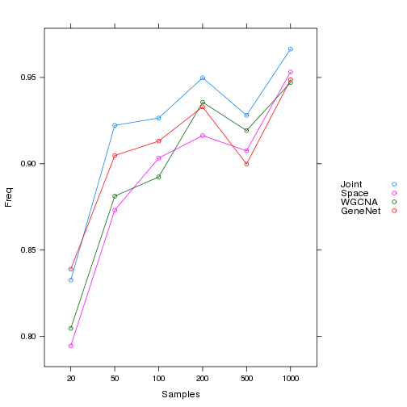

```r
library(lattice)
size <- SIZE[min(length(SIZE), 3)]
noise <- "0.25"
print(xyplot(Freq ~ Samples, group = Method, data = as.data.frame.table(AUCs[,
    size, , noise]), type = "b", auto.key = list(space = "right")))
```

And we can select on particular network from that graph and plot more specific information, such as the total number of identified connections vs. the number of false positives after reading in that network's results again.

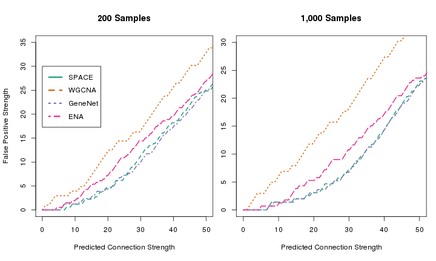

```r
par(mfrow = c(1, 2), mar = c(5.1, 4.1, 4.1, 0.6))

library(RColorBrewer)
colors <- brewer.pal(4, "Dark2")

# First plot

samples <- "200"
results <- readRDS(paste(resultsDir, size, "nSamp", samples, "Sigma",
    noise, ".Rds", sep = ""))

results$Truth <- as.integer(results$Truth != 0)

plot(0, 0, type = "n", xlim = c(0, 50), ylim = c(0, 35), xlab = "Predicted Connection Strength",
    ylab = "False Positive Strength", main = "200 Samples")
legend(0, 30, c("SPACE", "WGCNA", "GeneNet", "ENA"), col = colors,
    lwd = 3, lty = 1:4, y.intersp = 1.5)


#' Plots a single line of the total identifid on the x-axis vs the false
#' positives on the y-axis.  @param df the data frame to use in the format
#' of having the first column be the truth and the second column be the
#' predictions for this method @param color dictates the color of the line
#' plotted
plotPerformance <- function(df, color = 1, lty) {
    # normalize to 0:1
    df[, 2] <- df[, 2]/max(df[, 2])
    df <- df[order(df[, 2], decreasing = TRUE), ]
    df$FalsePos <- df[, 2]
    df$FalsePos[df$Truth == 1] <- 0

    # Done organizing the data.frame, now can format for plotting.
    df$FalsePos <- cumsum(df$FalsePos)
    df[, 2] <- cumsum(df[, 2])
    lines(x = c(0, df[, 2]), y = c(0, df[, 3]), col = color, lwd = 2, lty = lty)
}

sp <- results[, c(3, 4)]
plotPerformance(sp, colors[1], 2)

wg <- results[, c(3, 5)]
plotPerformance(wg, colors[2], 3)

gn <- results[, c(3, 6)]
plotPerformance(gn, colors[3], 4)

ena <- results[, c(3, 7)]
plotPerformance(ena, colors[4], 5)

## second plot

par(mar = c(5.1, 2.1, 4.1, 1.1))

samples <- "1000"

results <- readRDS(paste(resultsDir, size, "nSamp", samples, "Sigma",
    noise, ".Rds", sep = ""))

results$Truth <- as.integer(results$Truth != 0)

plot(0, 0, type = "n", xlim = c(0, 50), ylim = c(0, 30), xlab = "Predicted Connection Strength",
    ylab = "", main = "1,000 Samples")

sp <- results[, c(3, 4)]
plotPerformance(sp, colors[1], 2)

wg <- results[, c(3, 5)]
plotPerformance(wg, colors[2], 3)

gn <- results[, c(3, 6)]
plotPerformance(gn, colors[3], 4)

ena <- results[, c(3, 7)]
plotPerformance(ena, colors[4], 5)
```

### Rank Summary

The simplest way to analyze the relative pAUC or AUCs would just be to rank them, rather than trying to determine how “substantial” an improvement of .01 in the AUC, for instance, really is. So we can use the rank function, which will give us an order to all of the methods in which the highest ranked methods performed the best.

We could summarize these for a network size/sample size combination across all noise values, for instance. The code below does that, then further summarizes those summaries across all sample size values – producing a 2D table showing the average rank for a method at a network size across all noise and sample size values.

AUCs are shown here.

```r
rankAvg <- array(dim = c(length(METHODS), length(SIZE)), dimnames = list(Method = METHODS,
    Size = SIZE))
for (size in SIZE) {
    thisSize <- array(dim = c(length(NOISE), length(METHODS)), dimnames = list(Noise = NOISE,
        Method = METHODS))
    for (sigma in NOISE) {
        thisSize[as.character(sigma), ] <- apply(apply(AUCs[, size, , as.character(sigma)],
            "Samples", function(x) {
                rank(x, na.last = "keep")
            }), 1, mean)
    }
    rankAvg[, size] <- apply(thisSize, 2, mean)
}
rankAvg
```

```
##          Size
## Method     tiny small moderate middle large
##   Joint   2.875 3.333    3.375  3.500 3.458
##   Space   2.479 2.250    1.625  1.292 1.250
##   WGCNA   1.500 1.458    1.958  2.292 2.458
##   GeneNet 3.146 2.958    3.042  2.917 2.833
```

```r
apply(rankAvg, 2, rank)
```

```
##          Size
##           tiny small moderate middle large
##   Joint      3     4        4      4     4
##   Space      2     2        1      1     1
##   WGCNA      1     1        2      2     2
##   GeneNet    4     3        3      3     3
```

And pAUCs here.

```r
rankpAvg <- array(dim = c(length(METHODS), length(SIZE)), dimnames = list(Method = METHODS,
    Size = SIZE))
for (size in SIZE) {
    thisSize <- array(dim = c(length(NOISE), length(METHODS)), dimnames = list(Noise = NOISE,
        Method = METHODS))
    for (sigma in NOISE) {
        thisSize[as.character(sigma), ] <- apply(apply(pAUCs[, size, , as.character(sigma)],
            "Samples", function(x) {
                rank(x, na.last = "keep")
            }), 1, mean)
    }
    rankpAvg[, size] <- apply(thisSize, 2, mean)
}
rankpAvg
```

```
##          Size
## Method     tiny small moderate middle large
##   Joint   2.125 2.188    2.542  2.792 3.167
##   Space   3.188 3.125    3.125  3.125 2.750
##   WGCNA   1.417 1.396    1.417  1.375 1.708
##   GeneNet 3.271 3.292    2.917  2.708 2.375
```

```r
apply(rankpAvg, 2, rank)
```

```
##          Size
##           tiny small moderate middle large
##   Joint      2     2        2      3     4
##   Space      3     3        4      4     3
##   WGCNA      1     1        1      1     1
##   GeneNet    4     4        3      2     2
```

## Merge Datasets

This section will test the reconstruction of three different datasets using a naive merging approach and a meta-analysis approach based on ENA.

First, we'll read in three simulated datasets.

```r
#' Create a simulated randomized 'true' regulatory network based on the
#' truth file provided.  @param size should be one of
#' c('tiny','small','moderate','middle','large', 'huge') @author Jeffrey
#' D. Allen \email{Jeffrey.Allen@@UTSouthwestern.edu}
randomizeRegulation <- function(size) {
    dat <- read.csv(paste("../truth/", size, ".csv", sep = ""))

    dat <- dat[dat$Source != dat$Target, ]
    dat[dat$Source > dat$Target, ] <- dat[dat$Source > dat$Target, 2:1]
    dat[dat$Source > dat$Target, ]

    N <- dim(dat)[1]
    dat$regulation <- round(sign(rbinom(N, 1, 0.5) - 0.5) * rnorm(N, 0.5, 0.2),
        2)
    dat$type <- sign(dat$regulation)

    dat
}


#' Read the edge definition and simulate the regulation ###
#'
#' @param dat the regulatory truth obtained from randomizeRegulation()
#' @param sample can be any positive number.  @param noise can be any
#' positive number (for our study, we should try 0.25, 0.5, 0.75, 1, 1.5
#' and 2) @author Jeffrey D. Allen
#' \email{Jeffrey.Allen@@UTSouthwestern.edu}
network.simulation <- function(dat, sample, noise) {


    Gene <- union(dat$Source, dat$Target)
    nGene <- length(Gene)

    #### initiate the matrix expr to store the simulated expression level ####


    nSamp <- sample
    expr <- matrix(0, nGene, nSamp)
    rownames(expr) <- Gene
    colnames(expr) <- paste("S", 1:nSamp, sep = "")

    sigma <- noise

    unknown <- unique(dat$Target)
    known <- setdiff(Gene, unknown)

    for (i in known) {
        expr[as.character(i), ] <- rbinom(nSamp, 1, 0.5) * 2 + rnorm(nSamp,
            0, sigma) - 1
    }

    while (length(unknown) > 0) {
        for (i in unknown) {
            source <- as.character(dat$Source[dat$Target == i])
            if (all(source %in% known)) {
                val <- ifelse(rep(length(source) == 1, nSamp), expr[as.character(source),
                  ] * dat[dat$Target == i, 3], dat[dat$Target == i, 3] %*% expr[as.character(source),
                  ])
                expr[as.character(i), ] <- as.numeric(val > 0) * 2 - 1 + rnorm(nSamp,
                  0, sigma)
                known <- append(known, i)
                unknown <- setdiff(unknown, i)
            }
        }
    }

    round(expr, 2)
}

reg <- randomizeRegulation("middle")
sim25 <- network.simulation(reg, 200, 0.25)
sim1 <- network.simulation(reg, 200, 1)
sim2 <- network.simulation(reg, 200, 2)
```

```r
library(WGCNA)
library(GeneNet)
library(space)
library(ENA)
library(ROCR)
```

We'll first need a function to extract the true network for inclusion in our aggregated tables.

```r
#' Convert an adjacency-like list (which may or may not contain all the
#' gene IDs in the network) into an adjacency matrix.
#'
#' @param IDs A vector of Gene IDs in this network @param truthList An
#' adjacency list containing the truth to be converted to a matrix. Should
#' have vectors for 'Source', 'Target', and 'Regulation.'  @author Jeffrey
#' D. Allen \email{Jeffrey.Allen@@UTSouthwestern.edu}
truthToMat <- function(IDs, truthList) {
    truth <- matrix(0, ncol = length(IDs), nrow = length(IDs))
    rownames(truth) <- IDs
    colnames(truth) <- IDs
    diag(truth) <- 1
    for (i in 1:dim(truthList)[1]) {
        s <- truthList[i, ]$Source
        t <- truthList[i, ]$Target
        r <- truthList[i, ]$regulation
        truth[which(IDs == s), which(IDs == t)] <- r
    }
    truth <- symmetricize(truth, "ud")
    return(truth)
}
```

We'll then need a helper function which, given all of the information about a simulation, can extract the simulated dataset, aggregate the results into a table, and write the output.

```r
#' Read and process an expression matrix using all three methods and ENA
#' and return the generated results.  @param simul The simulated
#' expression data @param bootstrapCount The number of iterations to
#' perform while bootstrapping.  @param bootstrapPercentage The percentage
#' of available samples to include in each bootstrapped iteration.  @param
#' Cluster an MPI cluster to which we can distribute the work.  @param
#' truth The truth for the network -- can be combined into the resultant
#' output for easier analysis of performance later.  @author Jeffrey D.
#' Allen \email{Jeffrey.Allen@@UTSouthwestern.edu}
processMat <- function(simul, bootstrapCount = 140, bootstrapPercentage = 0.7,
    cluster, truth) {

    addressing <- getTableAddressing(rownames(simul), truth)

    sp <- bootstrap(simul, "buildSpace", cluster = cluster, iterations = bootstrapCount,
        sample.percentage = bootstrapPercentage)
    wg <- symmetricize(abs(buildWgcna(simul)))
    wg <- wg[upper.tri(wg)]
    gn <- bootstrap(simul, "buildGenenet", cluster = cluster, iterations = bootstrapCount,
        sample.percentage = bootstrapPercentage)

    joint1 <- ena(cbind(gn[, 3], wg, sp[, 3]))
    joint1 <- data.frame(addressing, sp[, 3], wg, gn[, 3], joint1, row.names = NULL)
    colnames(joint1) <- c("Source", "Dest", "Truth", "BootstrappedSPACE", "WGCNA",
        "BootstrappedGenenet", "ENA")
    # Since this graph is undirected, for consistency, make Source always
    # smaller than Dest
    allGenes <- union(joint1$Source, joint1$Dest)
    levels(joint1$Source) <- allGenes
    levels(joint1$Dest) <- allGenes
    joint1[as.character(joint1[, 1]) > as.character(joint1[, 2]), 1:2] <- joint1[as.character(joint1[,
        1]) > as.character(joint1[, 2]), 2:1]

    return(joint1)
}
```

We'll want to grab the truth for this network:

```r
truthList <- read.csv(paste("../truth/truth middle.csv", sep = ""))
truth <- truthToMat(rownames(sim2), truthList)
```

### Individual Network Reconstruction

We'll now reconstruct each of these networks individually.

```r
cluster <- NULL
if (require(Rmpi) && require(snow)) {
    invisible(capture.output(cluster <- makeCluster(mpi.universe.size() - 1,
        type = "MPI")))
    warning(paste("Distributing bootstrapped networks across a cluster of",
        mpi.universe.size() - 1, "CPUs."))
}
net25 <- processMat(sim25, cluster = cluster, truth = truth)
net1 <- processMat(sim1, cluster = cluster, truth = truth)
net2 <- processMat(sim2, cluster = cluster, truth = truth)
```

### Merged Network Reconstruction

We'll now want to compute the merged networks using either the naive method or the meta-analysis ENA method. We'll perform the naive first by just stacking the three simulations on top of one another.

```r
stackedSim <- cbind(sim25, sim1, sim2)
stackedNet <- processMat(stackedSim, cluster = cluster, truth = truth)
```

And the alternative ENA method can be performed by joining the three previous results.

```r
enaNet <- ena(cbind(net25$ENA, net1$ENA, net2$ENA))

save(enaNet, stackedNet, net25, net1, net2, file = "nets.Rda")
```

### Performance Review

We can now calculate the the ROCs/AUCs of these networks.

```r
truVec <- net25$Truth != 0
pred25 <- prediction(net25$ENA, truVec)
perf25 <- performance(pred25, "tpr", "fpr")
performance(pred25, "auc")@y.values[[1]]
```

```
## [1] 0.9496
```

```r
pred1 <- prediction(net1$ENA, truVec)
perf1 <- performance(pred1, "tpr", "fpr")
performance(pred1, "auc")@y.values[[1]]
```

```
## [1] 0.9444
```

```r
pred2 <- prediction(net2$ENA, truVec)
perf2 <- performance(pred2, "tpr", "fpr")
performance(pred2, "auc")@y.values[[1]]
```

```
## [1] 0.9036
```

```r
predStac <- prediction(stackedNet$ENA, truVec)
perfStac <- performance(predStac, "tpr", "fpr")
performance(predStac, "auc")@y.values[[1]]
```

```
## [1] 0.9631
```

```r
predENA <- prediction(enaNet, truVec)
perfENA <- performance(predENA, "tpr", "fpr")
performance(predENA, "auc")@y.values[[1]]
```

```
## [1] 0.9667
```

And plot them

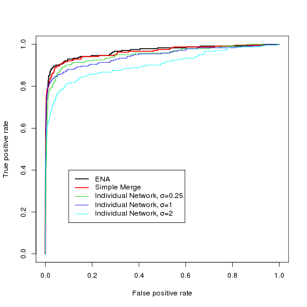

```r
plot(perfENA, col = 1, lwd = 2)
plot(perfStac, col = 2, lwd = 2, add = TRUE)
plot(perf25, col = 3, add = TRUE)
plot(perf1, col = 4, add = TRUE)
plot(perf2, col = 5, add = TRUE)
legend(0.1, 0.4, c("ENA", "Simple Merge", expression(paste("Individual Network, ",
    sigma, "=0.25", sep = "")), expression(paste("Individual Network, ", sigma,
    "=1", sep = "")), expression(paste("Individual Network, ", sigma, "=2",
    sep = ""))), col = 1:5, lwd = c(2, 2, 1, 1, 1))
```

## Test Bootstrapping

[figure not shown]

[figure not shown]

[figure not shown]

This section will compare the single execution of a networkreconstruction technique to a bootstrapped execution. The single execution will use all 100% of the samples in its construction, whereas the bootstrapped version will only use 70% each iteration.

We'll first define the function that will give us the resultant network from a single iteration of 100% and a series of smaller iterations at 70%.

```r
library(WGCNA)
library(GeneNet)
library(space)
library(ENA)
```

For this analysis, we really aren't concerned about the larger network, so we'll cut the size down.

```r
SIZE <- c("tiny", "small", "moderate", "middle")
```

```r
# ' Create a data.frame storing one single iteration of the selecte method
# along with multiple bootstrapped iterations of the function. This can
# later be used to analyze the performance of the ENA bootstrapping
# approach.  @param data the matrix of gene expression to reconstruct
# @param the character representation of the function to use to
# reconstruct @param iterations the number of iterations to bootstrap
# through @param cluster the MPI cluster to use when bootstrapping @param
# sample.percentage the percentage of total samples to use in each
# bootstrapped iteration.  @author Jeffrey D. Allen
# \email{Jeffrey.Allen@@UTSouthwestern.edu}
single_vs_bootstrapped <- function(data, fun, iterations = 500, cluster = NULL,
    sample.percentage = 0.7) {
    funName <- fun
    fun <- get(fun)
    funWrapper <- function(rand.seed, fun, data, sample.percentage, ...) {
        set.seed(rand.seed)
        sampledData <- data[, sample(1:ncol(data), round(sample.percentage *
            ncol(data)))]
        net <- symmetricize(abs(fun(sampledData)))
        return(net[upper.tri(net)])
    }
    toReturn <- getTableAddressing(rownames(data), truth)
    if (!missing(cluster) && "MPIcluster" %in% class(cluster)) {
        clusterExport(cluster, c("symmetricize"))
        result <- clusterApplyLB(cluster, 1:iterations, funWrapper, fun, data,
            sample.percentage)
    } else {
        result <- lapply(1:iterations, funWrapper, fun, data, sample.percentage)
    }
    result <- as.data.frame(result)
    colnames(result) <- 1:iterations

    single <- symmetricize(abs(fun(data)))
    single <- single[upper.tri(single)]

    toReturn <- cbind(single, result)
    colnames(toReturn)[1] <- "Single"

    return(toReturn)
}
```

We can now define a handful of functions used in analyzing the AUC of the above function.

```r
library(ROCR)
#' Compute the AUC of the given data @param truth a vector of binary truth
#' values @param predicted a vector of numeric prediction values.  @author
#' Jeffrey D. Allen \email{Jeffrey.Allen@@UTSouthwestern.edu}
getAUC <- function(truth, predicted) {
    pred <- prediction(predicted, truth)
    auc <- performance(pred, "auc")@y.values[[1]]
    auc
}

#' Compue the AUCs of all sequential ENA datasets in the provided
#' data.frame and return the AUCs.  @param mat the data.frame/matrix with
#' each column representing a single iteration's resultant network and
#' each row representing an edge in the network.  @param truth a vector of
#' binary truth values for each row in the provided matrix.
compute_ena_aucs <- function(mat, truth) {
    aucs <- NULL
    for (i in 1:ncol(mat)) {
        if (i != 1) {
            iter <- 1/((1/iter) + log(rank(-mat[, i]) + 1))
        } else {
            iter <- 1/(log(rank(-mat[, 1]) + 1))
        }
        aucs[i] <- getAUC(truth, iter)
    }
    aucs
}

#' Compute the compute_ena_aucs function on all three network
#' reconstruction techniques and return the diferences in the AUCs of each
#' method.  @param data the expression data on which reconstruction will
#' be applied @param truth the binary truth matrix for this data @param
#' cluster the MPI cluster across which to distribute the work.  @author
#' Jeffrey D. Allen \email{Jeffrey.Allen@@UTSouthwestern.edu}
bootstrapNetwork <- function(data, truth, iterations, cluster = cluster) {
    sp <- single_vs_bootstrapped(data, "buildSpace", iterations = iterations,
        cluster = cluster)
    spAUC <- getAUC(truth, sp$Single)
    spBoot <- compute_ena_aucs(sp[, -1], truth)

    wg <- single_vs_bootstrapped(data, "buildWgcna", iterations = iterations,
        cluster = cluster)
    wgAUC <- getAUC(truth, wg$Single)
    wgBoot <- compute_ena_aucs(wg[, -1], truth)

    gn <- single_vs_bootstrapped(data, "buildGenenet", iterations = iterations,
        cluster = cluster)
    gnAUC <- getAUC(truth, gn$Single)
    gnBoot <- compute_ena_aucs(gn[, -1], truth)

    results <- array(NA, dim = c(3, iterations), dimnames = list(Method = c("SPACE",
        "WGCNA", "GeneNet"), Iteration = 1:iterations))

    results["SPACE", ] <- spBoot - spAUC
    results["WGCNA", ] <- wgBoot - wgAUC
    results["GeneNet", ] <- gnBoot - gnAUC

    # note that you can use as.data.frame.table(results) to flatten these
    # results into a data.frame (i.e. for ggplotting.)

    list(SPACE = spAUC, WGCNA = wgAUC, GeneNet = gnAUC, diff = results)
}


#' Convert an adjacency-like list (which may or may not contain all the
#' gene IDs in the network) into an adjacency matrix.
#'
#' @param IDs A vector of Gene IDs in this network @param truthList An
#' adjacency list containing the truth to be converted to a matrix. Should
#' have vectors for 'Source', 'Target', and 'Regulation.'  @author Jeffrey
#' D. Allen \email{Jeffrey.Allen@@UTSouthwestern.edu}
truthToMat <- function(IDs, truthList) {
    truth <- matrix(0, ncol = length(IDs), nrow = length(IDs))
    rownames(truth) <- IDs
    colnames(truth) <- IDs
    diag(truth) <- 1
    for (i in 1:dim(truthList)[1]) {
        s <- truthList[i, ]$Source
        t <- truthList[i, ]$Target
        r <- truthList[i, ]$regulation
        truth[which(IDs == s), which(IDs == t)] <- r
    }
    truth <- symmetricize(truth, "ud")
    return(truth)
}

#' Get a binary vector of truth for the given size corresponding to the
#' upper triangle of the dataset.  @param size one of 'tiny', 'small',
#' 'moderate', 'middle', or 'large' @author Jeffrey D. Allen
#' \email{Jeffrey.Allen@@UTSouthwestern.edu}
getTruth <- function(size) {
    truthList <- read.csv(paste("../truth/truth ", size, ".csv", sep = ""))
    simul <- read.csv(paste("../data/simulations/", size, "nSamp", NP[1], "Sigma",
        NOISE[1], ".csv", sep = ""), row.names = 1)
    truth <- truthToMat(rownames(simul), truthList)
    addr <- getTableAddressing(rownames(truth), truth)
    truth <- addr$Truth != 0

    truth
}

#' Get the expression data fora particular network size, sample number,
#' and noise value.  @author Jeffrey D. Allen
#' \email{Jeffrey.Allen@@UTSouthwestern.edu}
getExpression <- function(size, np, sigma) {
    data <- read.csv(paste("../data/simulations/", size, "nSamp", np, "Sigma",
        sigma, ".csv", sep = ""), row.names = 1)
    data
}
```

We can plot out a very thorough comparison of the difference between the single and bootstrapped methods.

```r
iterations <- 200
AUCs <- array(NA, dim = c(length(SIZE), length(NP), length(NOISE),
    3, iterations), dimnames = list(Size = SIZE, Samples = NP, Sigma = NOISE,
    Method = c("SPACE", "WGCNA", "GeneNet"), Iteration = 1:iterations))

cluster <- NULL
if (require(Rmpi) && require(snow)) {
    invisible(capture.output(cluster <- makeCluster(mpi.universe.size() - 1,
        type = "MPI")))
    warning(paste("Distributing bootstrapped networks across a cluster of",
        mpi.universe.size() - 1, "CPUs."))
}
```

We can compute all of the AUC improvements over every network.

```r
truth <- NULL
for (size in SIZE) {
    truth <- getTruth(size)
    for (np in NP) {
        cat(np, "\n")
        for (sigma in NOISE) {
            cat("\t", sigma, "\n")

            thisNet <- bootstrapNetwork(getExpression(size, np, sigma), truth,
                iterations = iterations, cluster = cluster)

            AUCs[size, np, sigma, , ] <- thisNet$diff
        }
    }
    saveRDS(AUCs, "AUCs.Rds")
}
```

And we can identify for which methods bootstrapping is benefeicial:

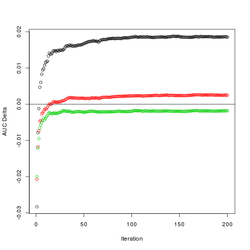

```r
plot(apply(AUCs[, , , "SPACE", ], 4, mean, na.rm = TRUE), ylab = "AUC Delta",
    xlab = "Iteration")
points(apply(AUCs[, , , "GeneNet", ], 4, mean, na.rm = TRUE), col = 2)
points(apply(AUCs[, , , "WGCNA", ], 4, mean, na.rm = TRUE), col = 3)
abline(h = 0)
```

We can rule out WGCNA as a potential method which might be helped by bootstrapping.

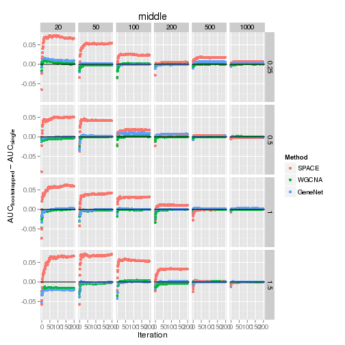

```r
library(ggplot2)
for (size in SIZE) {
    AUCtab <- as.data.frame.table(AUCs[size, , , , ], responseName = "AUC")
    AUCtab$Iteration <- as.integer(as.character(AUCtab$Iteration))
    print(ggplot(AUCtab, aes(Iteration, AUC, color = Method, group = Method)) +
        geom_point() + facet_grid(Sigma ~ Samples) + geom_hline(aes(yintercept = 0)) +
        ggtitle(size) + ylab(bquote(AUC[bootstrapped] - AUC[single])))
}
```

[output not shown]

[output not shown]

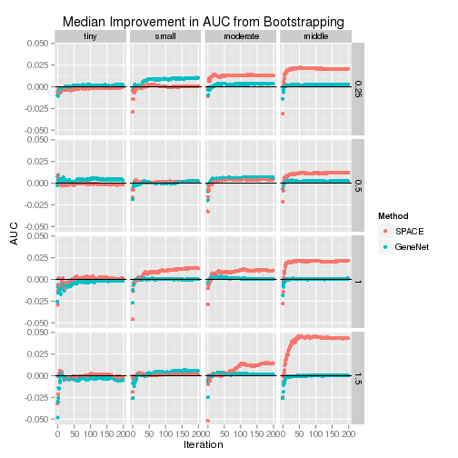

```r
AUCtab <- as.data.frame.table(AUCs[, , , , ], responseName = "AUC")
AUCtab$Iteration <- as.integer(as.character(AUCtab$Iteration))


AUCavg <- as.data.frame.table(apply(AUCs[, , , c("SPACE", "GeneNet"),
    ], c(1, 3, 4, 5), median, na.rm = TRUE), responseName = "AUC")
AUCavg$Iteration <- as.integer(as.character(AUCavg$Iteration))
ggplot(AUCavg, aes(Iteration, AUC, group = Method, col = Method)) +
    facet_grid(Sigma ~ Size) + geom_point() + geom_hline(aes(yintercept = 0)) +
    opts(title = "Median Improvement in AUC from Bootstrapping")
```

[figure not shown]

```r
AUCres <- as.data.frame.table(AUCs[, , , , 140], responseName = "AUC")

ggplot(AUCres, aes(Samples, AUC, fill = Method)) + geom_boxplot() +
    ylab(bquote(AUC[single] - AUC[bootstrapped])) + geom_hline(aes(yintercept = 0))
```

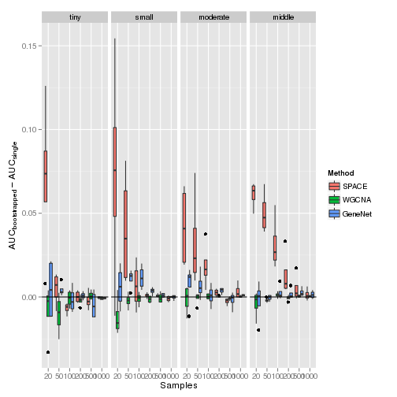

```r
ggplot(AUCres, aes(Samples, AUC, fill = Method)) + geom_boxplot() +
    ylab(bquote(AUC[bootstrapped] - AUC[single])) + facet_grid(. ~ Size) + geom_hline(aes(yintercept = 0))
```

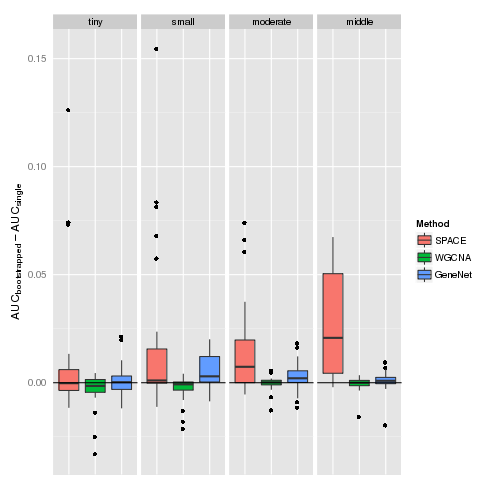

```r
ggplot(AUCres, aes(Method, AUC, fill = Method)) + geom_boxplot() +
    ylab(bquote(AUC[bootstrapped] - AUC[single])) + facet_grid(. ~ Size) + geom_hline(aes(yintercept = 0)) +
    theme(axis.ticks = element_blank(), axis.text.x = element_blank()) + xlab("")
```

```r
size <- SIZE[min(length(SIZE), 4)]
sigma <- "0.25"
truth <- getTruth(size)

# Note that the AUCs we're reading in actually are from the bootstrapped
# network construction, so for plotting purposes we'll actually want to
# subtract the diff to compute the single AUC, as this is already the
# bootstrapped AUC.
actualAUC <- readRDS("../aucs/AUCs.Rds")
actualAUC <- actualAUC[, size, , sigma]
AUCdelta <- AUCs
```

Now we can plot the individual figures for each method.

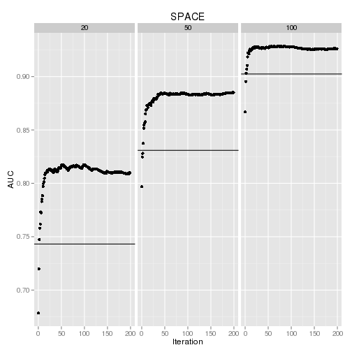

```r
offset <- AUCdelta[size, NP[1:3], sigma, "SPACE", "140"]
AUCdelta[size, NP[1:3], sigma, "SPACE", ] <- AUCdelta[size, NP[1:3],
    sigma, "SPACE", ] + actualAUC["Space", NP[1:3]] - offset

AUCsp <- as.data.frame.table(AUCdelta[size, NP[1:3], sigma, "SPACE",
    ], responseName = "AUC")
AUCsp$Iteration <- as.integer(as.character(AUCsp$Iteration))
hline.data <- as.data.frame.table(actualAUC["Space", NP[1:3]] - offset)
colnames(hline.data) <- c("Samples", "orig")
ggplot(AUCsp, aes(Iteration, AUC)) + facet_grid(. ~ Samples) + geom_point() +
    geom_hline(aes(yintercept = orig), hline.data) + ggtitle("SPACE")
```

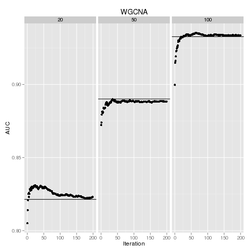

```r
offset <- AUCdelta[size, NP[1:3], sigma, "WGCNA", "140"]
AUCdelta[size, NP[1:3], sigma, "WGCNA", ] <- AUCdelta[size, NP[1:3],
    sigma, "WGCNA", ] + actualAUC["WGCNA", NP[1:3]] - offset

AUCsp <- as.data.frame.table(AUCdelta[size, NP[1:3], sigma, "WGCNA",
    ], responseName = "AUC")
AUCsp$Iteration <- as.integer(as.character(AUCsp$Iteration))
hline.data <- as.data.frame.table(actualAUC["WGCNA", NP[1:3]] - offset)
colnames(hline.data) <- c("Samples", "orig")
ggplot(AUCsp, aes(Iteration, AUC)) + facet_grid(. ~ Samples) + geom_point() +
    geom_hline(aes(yintercept = orig), hline.data) + ggtitle("WGCNA")
```

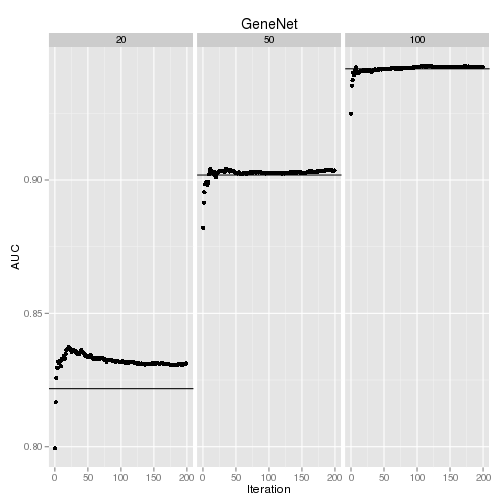

```r
offset <- AUCdelta[size, NP[1:3], sigma, "GeneNet", "140"]
AUCdelta[size, NP[1:3], sigma, "GeneNet", ] <- AUCdelta[size, NP[1:3],
    sigma, "GeneNet", ] + actualAUC["GeneNet", NP[1:3]] - offset

AUCsp <- as.data.frame.table(AUCdelta[size, NP[1:3], sigma, "GeneNet",
    ], responseName = "AUC")
AUCsp$Iteration <- as.integer(as.character(AUCsp$Iteration))
hline.data <- as.data.frame.table(actualAUC["GeneNet", NP[1:3]] -
    offset)
colnames(hline.data) <- c("Samples", "orig")
ggplot(AUCsp, aes(Iteration, AUC)) + facet_grid(. ~ Samples) + geom_point() +
    geom_hline(aes(yintercept = orig), hline.data) + ggtitle("GeneNet")
```

And we'll restore the SIZE variable for later use.

```r
SIZE <- c("tiny", "small", "moderate", "middle", "large")
```

Copyright ©2012-2013, The University of Texas Southwestern Medical Center. All rights reserved.